# Polar Bear Demography

Development of service for evaluation of polar bear demographic features

Nikita Platonov** Evgeny Ivanov Ilia Mordvintsev Sergey Naidenko Viatcheslav Rozhnov *A. N. Severtsov Institute of Ecology and Evolution* *Russian Academy of Sciences, Moscow

X<sup>th</sup> International Conference **«Marine Mammals of the Holarctic» 2018** Arkhangelsk, 30 October 2018

# Motivation

###### Motivation

- Connection of individual demographical parameters to the holistic demographical system to reduce data lack.
- Using the most sensitive demographical parameters as a metric for estimating of population status
- Involving into design and analysis of polar bear researches
- Verification of results obtained by other approaches.

# Alternatives

###### Alternatives

## Riskman

Population Modelling for Sustainability Assessment

[figure not shown]

## Riskman

Results of stochastic simulation

[figure not shown]

Can be exported.

## Riskman

Detailed parameterization

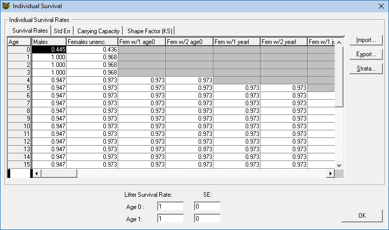

Completeness of estimates.

## Matrix Projection Model

Available as R (R Core Team, 2018) package **popdemo** (Stott *et al.*, 2018) with data for Beaufort Sea (Hunter *et al.*, 2010).

Six parameters: 2-year-old (0.106), 3-year-old (0.068), 4-year-old (0.106), adult available to breed (0.461), adult with cub (0.151), adult with yearling (0.108).

## Matrix Projection Model

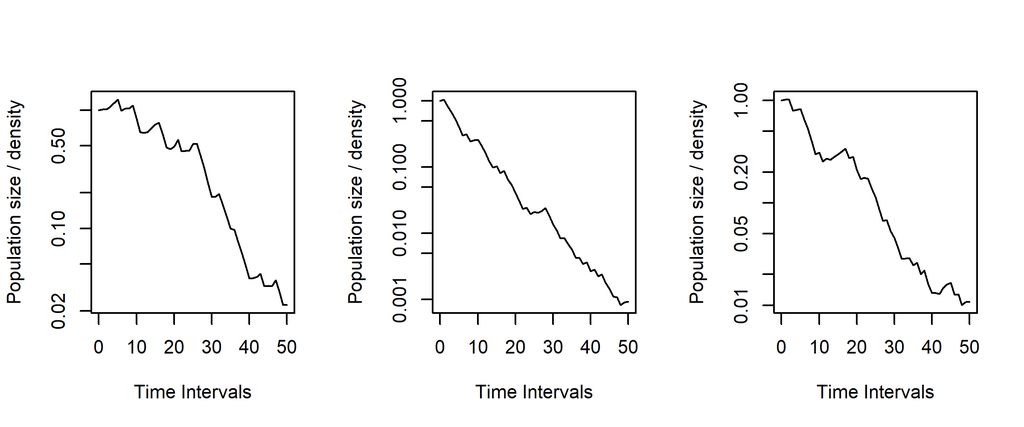

Consequent random repetitions one of conditions 2001-2005, where conditions 2001-2003 are good, and 2004-2005 are poor.

# Delelopment

###### Delelopment

- Standalone R (R Core Team, 2018) local application
- Shiny web application (“dashboard” with tabs)

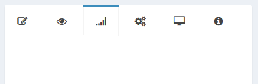

Hosted on https://github.com/nplatonov/demography. Licence MIT.

## shinyapps.io

[interactive chart not shown]

## Shiny tabs: Input

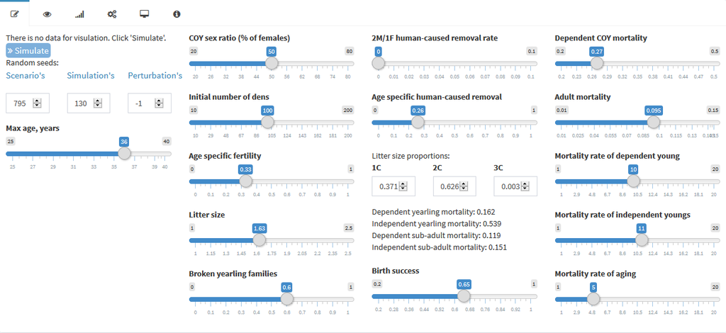

Set of sliders for data input

## Shiny tabs: Check

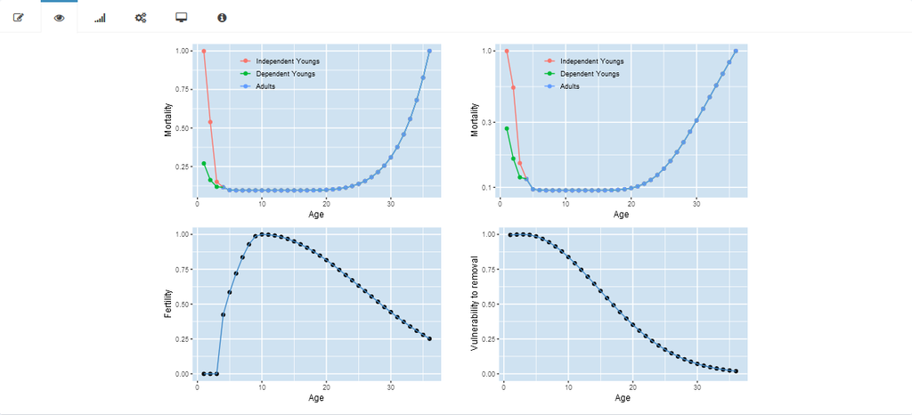

Visualization for overview of inputted data.

## Shiny tabs: Results

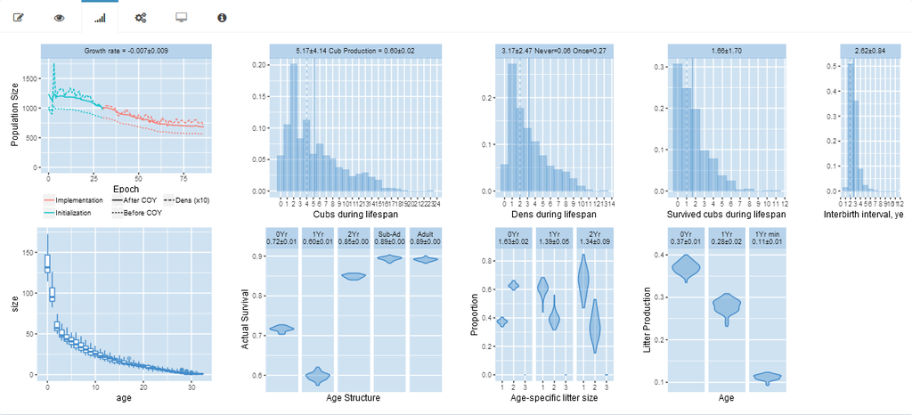

Visualization of results of simulation

## Shiny tabs: Perturbation

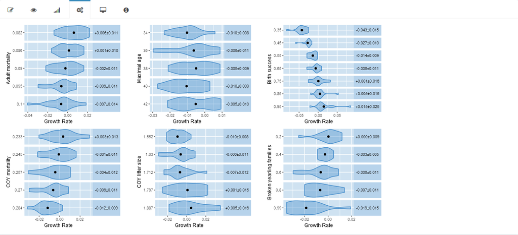

Visualization for single-variable adjustment to equilibrium growth rate.

# Approaches

###### Approaches

## Stochastic simulation

Randomized selection.

- Randomized scenarios for learning purposes with fixed random seed number for reproducible researches.
- Randomized simulation for with fixed random seed number for reproducible researches.

  No portion of individuals. No half of *last bear*: either “Yes” or “No”. Occasional choice for multiple sample.

  Increasing size of modelled population increases precision of applied demographical parameters.

## Time of census for annual score

Time of census for annual score is period of cubs emergence. At the same time, two states of population are considered:

- Applying “+1 year” aging, applying annual mortality – all without COYs (minimal population size).
- COYs are taken into account (maximal population size).

## Inter-generation relation

Named unique identifier for each individual for all peers and generations.

Connection between mother and dependent cubs; is canceled for independent cubs.

## Litter size is from 1 to 3 cubs

Current realization takes only COY litter size from inputs; litter fraction is a function of litter size.

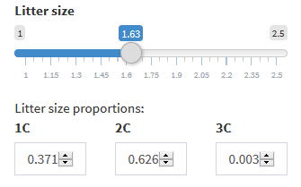

There is no limitation to consider litter size from 1 to 4 cubs.

## Survival at young age

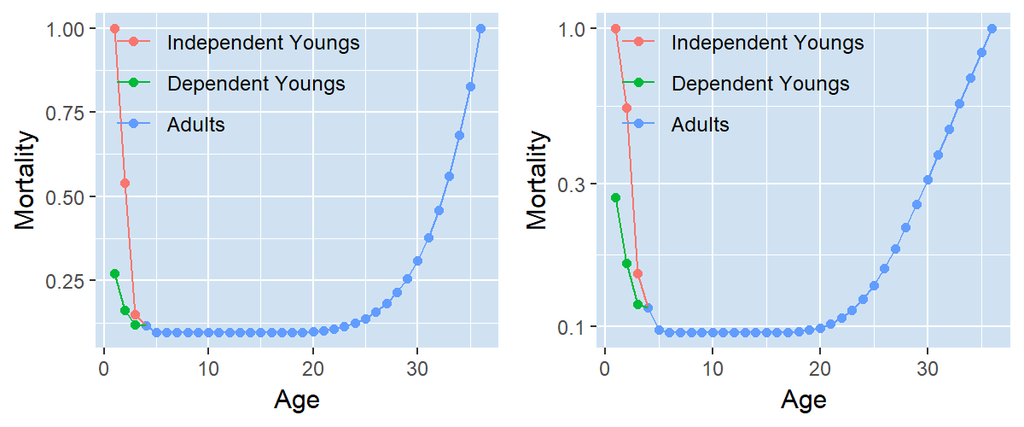

Mothers leave their cubs up to age both 1 and 2 years old.

Separate age specific survival rates for dependent and independent cubs.

## Survival at old age

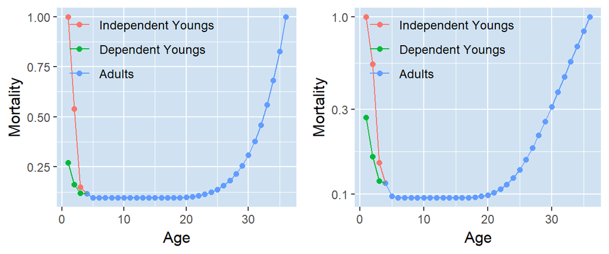

Survival of older individuals decreases with aging (Gompertz–Makeham law of mortality)

## Age-specific female fertility

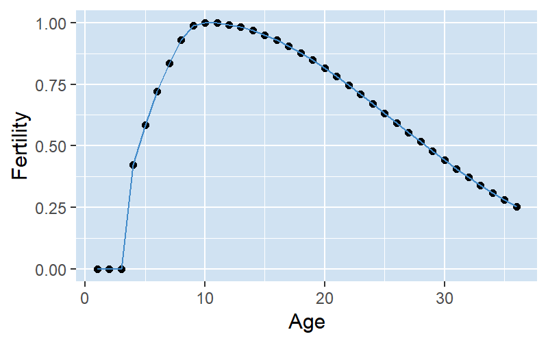

# Results

## Growth rate

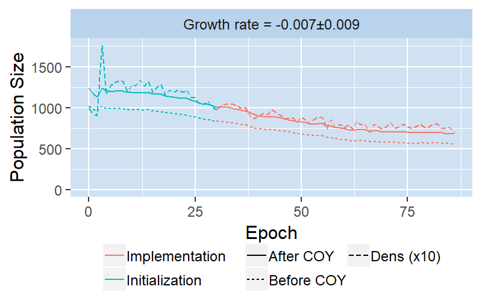

## Population peer structure

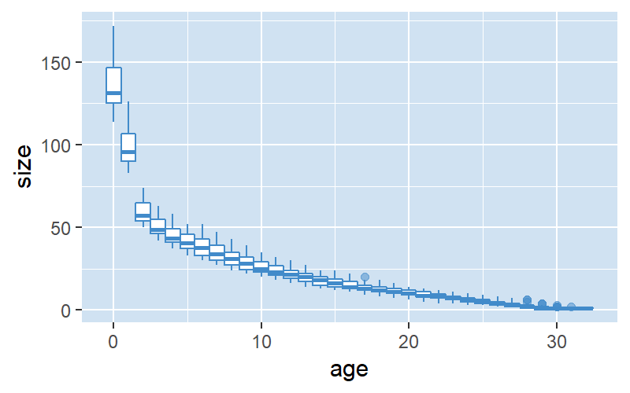

## Survival of different age groups

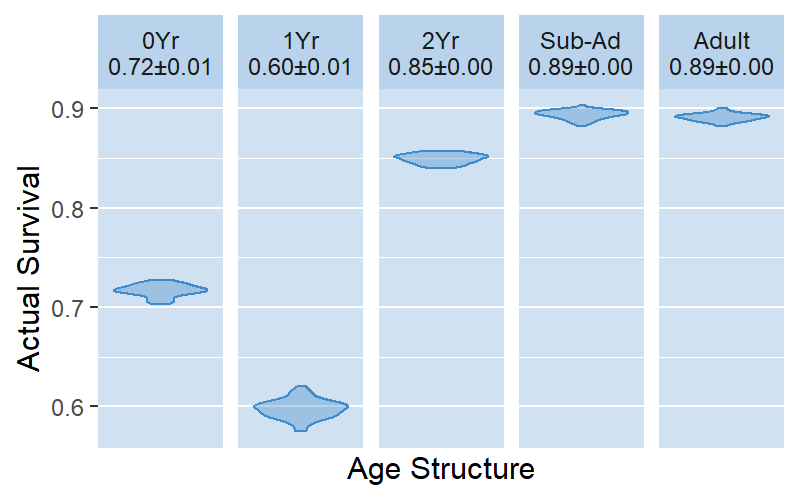

## Age-specific litter size

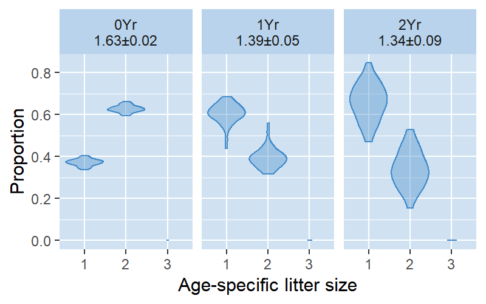

## Dens during lifespan

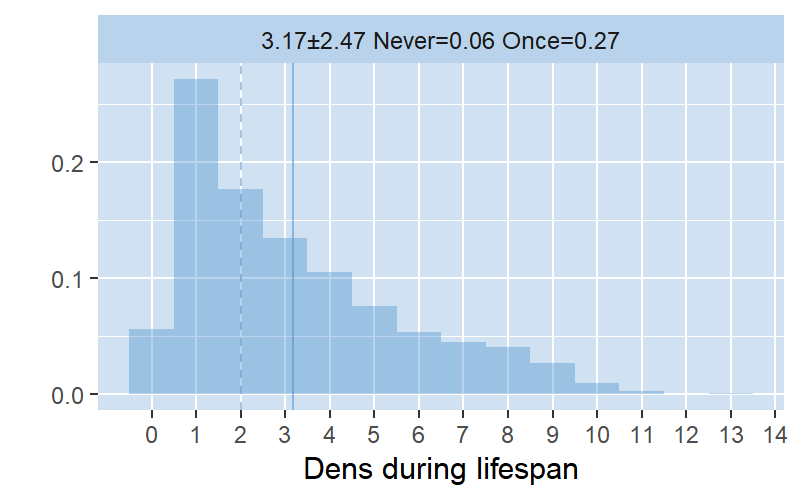

## Cubs during lifespan

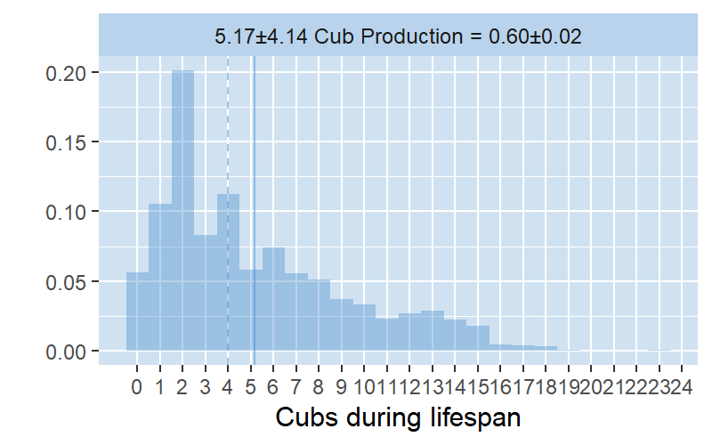

## Survived cubs during lifespan

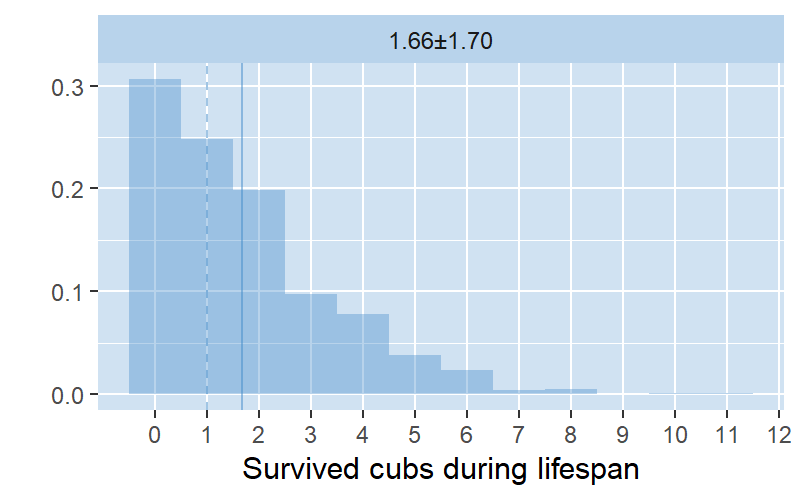

## Interbirth interval

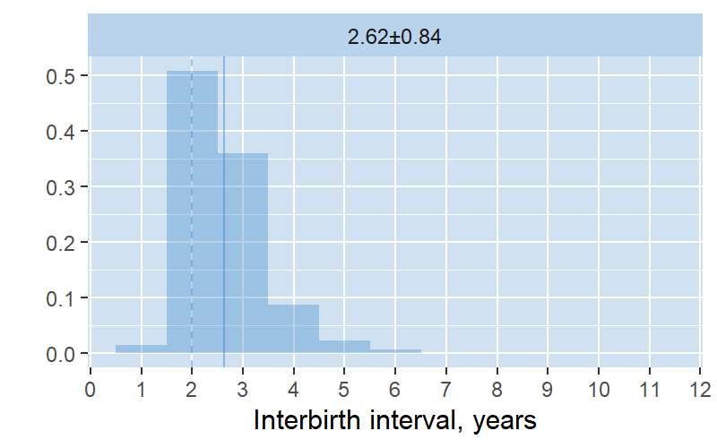

Re-mating *by assuming monthly COYs mortality during May-June and constant value of probability*.

# Thank you

## Submitted abstract

The dynamical simulation for evaluation of polar bear (*Ursus maritimus*) demography has been developed. On each stage, the change of age and sexual structure (with explicit mother-cub relations) of modelled subpopulation is forced by specified demographical parameters. The followed approaches and statements are considered: temporal resolution is one year, time of census is period of cubs emergence; litter size is 1 to 3 cubs; Gompertz–Makeham law of mortality is involved; the female fertility is age-specific; mothers leave their cubs in both ages of 1 and 2, and age-specific survival rates for dependent and independent cubs is different. All selections are random, and calculations are integer.

This service allows extracting generalized features of polar bear demography. On the average, interbirth (mating) interval is 2-3 years; it depends how long cubs remain with their mothers. A half of females gives birth to 3-4 litters or less during their lifespan; the long-lived females can produce 11-12 litters or less. The single and double births are most frequent, and frequency of each subsequent appearance of cubs falls. In general, among all cubs having a birth from one female during her lifespan only two ones or less reach the age 3 or older.

Relevant data inputs expand set of extracted demographical features. For example, averaged estimates of litter size (1.69, cubs of the year), cub production rate (0.63), litter production rate of cubs of the year (0.36) and yearlings (0.13) for polar bears in the western part of the Barents Sea from Environmental monitoring of Svalbard and Jan Mayen (MOSJ) were defined as target indicators. Several sets of demographical parameters for which these indicators are achieved were selected. Generally, the birth success is near 0.65-0.70, and around 45-50 % of females wean cubs before age of two.

Project is hosted on https://github.com/nplatonov/demography.

## References

Hunter CM, Caswell H, Runge MC, Regehr EV, Amstrup SC, Stirling I. 2010. Climate change threatens polar bear populations: A stochastic demographic analysis. *Ecology*, 91(10): 2883–2897. Wiley. doi:10.1890/09-1641.1

R Core Team. 2018. *R: A language and environment for statistical computing*. R Foundation for Statistical Computing: Vienna, Austria https://www.R-project.org/

Stott I, Hodgson D, Townley S. 2018. *Popdemo: Demographic Modelling Using Projection Matrices*. R package version 1.3-0. https://CRAN.R-project.org/package=popdemo (accessed 16 July 2018).